# Emacs as a programming IDE

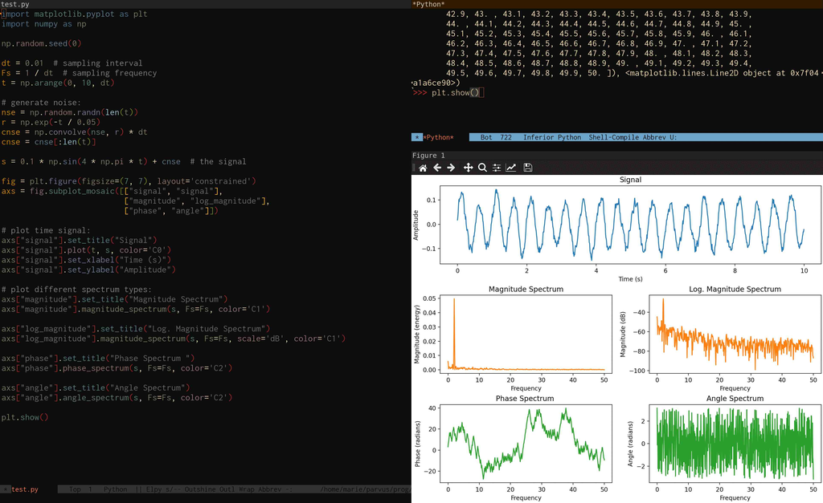

Marie-Hélène Burle

November 14, 2023

I am not trying to start [an editor war](https://en.wikipedia.org/wiki/Editor_war) here

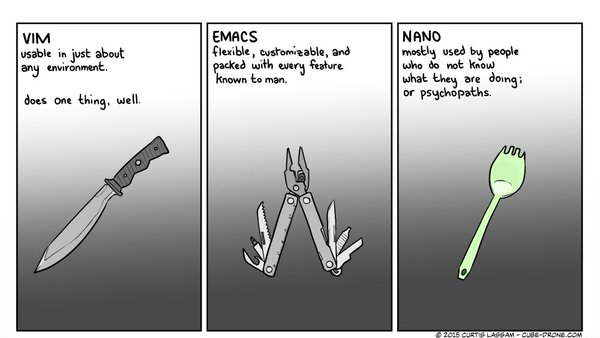

https://cube-drone.com

Particularly as there are now excellent IDEs for Python, Julia, and R without Emacs learning curve (think [VS Code](https://code.visualstudio.com/), [RStudio](https://posit.co/download/rstudio-desktop/), or [JupyterLab](https://jupyter.org/))

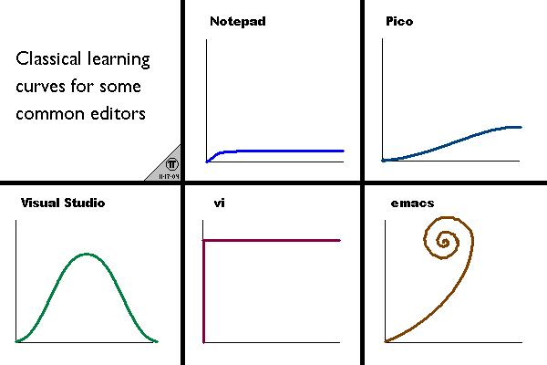

# Why I still use (and love) Emacs

Bookmarking

Fully customizable

Kbd for everything

Org mode (org tables!)

Organization of windows

Search and replace with regexp

[Ediff](https://www.gnu.org/software/emacs/manual/html_mono/ediff.html)

Macros

Emacs everywhere (emails, Slack, Telegram with [mu4e](https://github.com/djcb/mu), emacs-slack, [telega](https://github.com/zevlg/telega.el))

## [Helm](https://github.com/emacs-helm/helm)

Searching in buffer

Navigating open buffers and recent files

Navigating file sections

Selecting from kill ring

Moving in mark ring

Looking at active modes

## Completion

company-mode

yasnippet

[Dynamic abbrev expansion](https://www.gnu.org/software/emacs/manual/html_node/emacs/Abbrevs.html)

## Undoing/redoing with undo-tree

### Linear systems: classic undo/redo

```
flowchart TD
   1((" ")):::current
   classDef current stroke: #f96, stroke-width: 2px
```

Have some file

### Linear systems: classic undo/redo

```
flowchart TD
   1((" "))---2((" ")):::current
   classDef current stroke: #f96, stroke-width: 2px
```

Make some edits

### Linear systems: classic undo/redo

```
flowchart TD
   1((" "))---2((" "))---3((" ")):::current
   classDef current stroke: #f96, stroke-width: 2px
```

Make more edits

### Linear systems: classic undo/redo

```
flowchart TD
   1((" "))---2((" "))---3((" "))---4((" ")):::current
   classDef current stroke: #f96, stroke-width: 2px
```

Make more edits

### Linear systems: classic undo/redo

```
flowchart TD
   1((" "))---2((" "))---3((" ")):::current---4((" "))
   classDef current stroke: #f96, stroke-width: 2px
```

Can undo

### Linear systems: classic undo/redo

```
flowchart TD
   1((" "))---2((" ")):::current---3((" "))---4((" "))
   classDef current stroke: #f96, stroke-width: 2px
```

Undo some more

### Linear systems: classic undo/redo

```
flowchart TD
   1((" "))---2((" "))---3((" ")):::current---4((" "))
   classDef current stroke: #f96, stroke-width: 2px
```

Can redo

### Linear systems: classic undo/redo

```
flowchart TD
   1((" "))---2((" "))---3((" "))-.-4((" ")):::lost
   3((" "))---5((" ")):::current
   classDef current stroke: #f96, stroke-width: 2px
   classDef lost stroke-dasharray: 3 4
```

Make new edits

### Linear systems: classic undo/redo

```
flowchart TD
   1((" "))---2((" "))---3((" ")):::current-.-4((" ")):::lost
   3((" "))---5((" "))
   classDef current stroke: #f96, stroke-width: 2px
   classDef lost stroke-dasharray: 3 4
```

Can still undo

### Linear systems: classic undo/redo

```
flowchart TD
   1((" "))---2((" ")):::current---3((" "))-.-4((" ")):::lost
   3((" "))---5((" "))
   classDef current stroke: #f96, stroke-width: 2px
   classDef lost stroke-dasharray: 3 4
```

Can still undo

### Linear systems: classic undo/redo

```
flowchart TD
   1((" "))---2((" "))---3((" ")):::current-.-4((" ")):::lost
   3((" "))---5((" "))
   classDef current stroke: #f96, stroke-width: 2px
   classDef lost stroke-dasharray: 3 4
```

And can redo

### Linear systems: classic undo/redo

```
flowchart TD
   1((" "))---2((" "))---3((" "))-.-4((" ")):::lost
   3((" "))---5((" ")):::current
   classDef current stroke: #f96, stroke-width: 2px
   classDef lost stroke-dasharray: 3 4
```

But some edits are forever lost

### Linear systems: Emacs

```
---
config:
  themeVariables:
    fontSize: 10
  rankSpacing: 10
---
flowchart TD
   1((1)):::current
   classDef current stroke: #f96, stroke-width: 2px, color: #f96
```

Have some file

### Linear systems: Emacs

```
---
config:
  rankSpacing: 10
---
flowchart TD
   1((1))---2((2)):::current
   classDef current stroke: #f96, stroke-width: 2px, color: #f96
```

Make some edits

### Linear systems: Emacs

```
---
config:
  rankSpacing: 10
---
flowchart TD
   1((1))---2((2))---3((3)):::current
   classDef current stroke: #f96, stroke-width: 2px, color: #f96
```

Make more edits

### Linear systems: Emacs

```
---
config:
  rankSpacing: 10
---
flowchart TD
   1((1))---2((2))---3((3))---4((4)):::current
   classDef current stroke: #f96, stroke-width: 2px, color: #f96
```

Make more edits

### Linear systems: Emacs

```
---
config:
  rankSpacing: 10
---
flowchart TD
   1((1))---2((2))---3((3))---4((4))---5((3)):::current
   classDef current stroke: #f96, stroke-width: 2px, color: #f96
```

The first undo adds a new point to the chain of edits

### Linear systems: Emacs

```
---
config:
  rankSpacing: 10
---
flowchart TD
   1((1))---2((2))---3((3))---4((4))---5((3))---6((2)):::current
   classDef current stroke: #f96, stroke-width: 2px, color: #f96
```

More undoing keeps adding points to the chain

### Linear systems: Emacs

```
---
config:
  rankSpacing: 10
---
flowchart TD
   1((1))---2((2))---3((3))---4((4))---5((3))---6((2))---7((3)):::current
   classDef current stroke: #f96, stroke-width: 2px, color: #f96
```

There is no redo: you stop undoing, then start again to undo the undo

### Linear systems: Emacs

```
---
config:
  rankSpacing: 10
---
flowchart TD
   1((1))---2((2))---3((3))---4((4))---5((3))---6((2))---7((3))---8((5)):::current
   classDef current stroke: #f96, stroke-width: 2px, color: #f96
```

You can make new edits

Nothing ever gets lost, but you might get headaches

Example: let’s go back to the starting point

### Linear systems: Emacs

```
---
config:
  rankSpacing: 10
---
flowchart TD
   1((1))---2((2))---3((3))---4((4))---5((3))---6((2))---7((3))---8((5))---9((3))---10((2))---11((3))---12((4))---13((3))---14((2))---15((1)):::current
   classDef current stroke: #f96, stroke-width: 2px, color: #f96
```

### Non linear system: undo-tree

```
flowchart TD
   1((" ")):::current
   classDef current stroke: #f96, stroke-width: 2px, color: #f96
```

Have some file

### Non linear system: undo-tree

```
flowchart TD
   1((" "))---2((" ")):::current
   classDef current stroke: #f96, stroke-width: 2px, color: #f96
```

Make some edits

### Non linear system: undo-tree

```
flowchart TD
   1((" "))---2((" "))---3((" ")):::current
   classDef current stroke: #f96, stroke-width: 2px, color: #f96
```

Make some edits

### Non linear system: undo-tree

```
flowchart TD
   1((" "))---2((" "))---3((" "))---4((" ")):::current
   classDef current stroke: #f96, stroke-width: 2px, color: #f96
```

Make some edits

### Non linear system: undo-tree

```
flowchart TD
   1((" "))---2((" "))---3((" ")):::current---4((" "))
   classDef current stroke: #f96, stroke-width: 2px, color: #f96
```

Undo

### Non linear system: undo-tree

```
flowchart TD
   1((" "))---2((" ")):::current---3((" "))---4((" "))
   classDef current stroke: #f96, stroke-width: 2px, color: #f96
```

Undo

### Non linear system: undo-tree

```
flowchart TD
   1((" "))---2((" "))---3((" ")):::current---4((" "))
   classDef current stroke: #f96, stroke-width: 2px, color: #f96
```

Redo

### Non linear system: undo-tree

```
flowchart TD
   1((" "))---2((" "))---3((" "))---4((" "))
   3((" "))---5((" ")):::current
   classDef current stroke: #f96, stroke-width: 2px, color: #f96
```

Make new edits

### Non linear system: undo-tree

```
flowchart TD
   1((" "))---2((" "))---3((" "))---4((" "))
   3((" ")):::current---5((" "))
   classDef current stroke: #f96, stroke-width: 2px, color: #f96
```

Undo

### Non linear system: undo-tree

```
flowchart TD
   1((" "))---2((" "))---3((" "))---4((" ")):::current
   3((" "))---5((" "))
   classDef current stroke: #f96, stroke-width: 2px, color: #f96
```

Switch branch and redo the old version

### Non linear system: undo-tree

```
flowchart TD
   1((" ")):::current---2((" "))---3((" "))---4((" "))
   3((" "))---5((" "))
   classDef current stroke: #f96, stroke-width: 2px, color: #f96
```

Nothing gets lost and it is more sane to navigate the history

# Emacs with Python

Emacs comes with a Python mode that provides syntax highlighting. For a full IDE experience, there are multiple options, the most popular of which being the elpy package

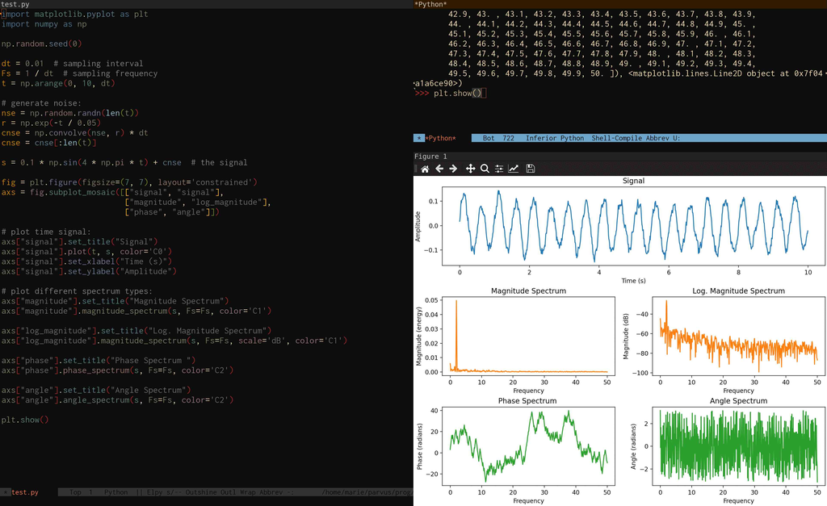

Code from [matplotlib](https://matplotlib.org/stable/gallery/lines_bars_and_markers/spectrum_demo.html#sphx-glr-gallery-lines-bars-and-markers-spectrum-demo-py)

# Emacs with R

R is—as Emacs—GNU software and has been integrated with Emacs via the [ESS (Emacs Speaks Statistics)](https://github.com/emacs-ess/ESS) package for a very long time

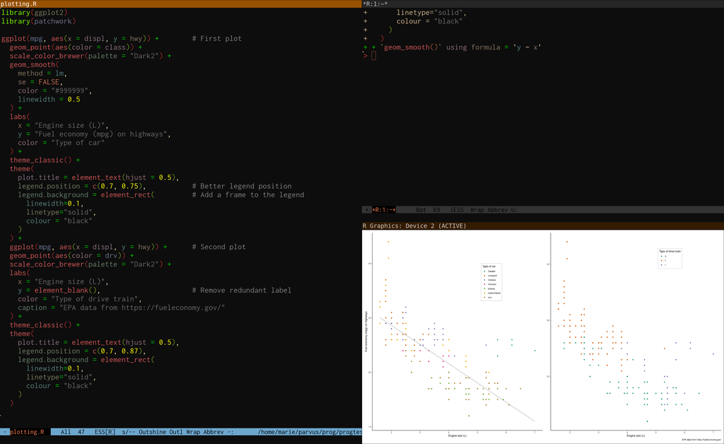

# Emacs with Julia

The [julia-mode](https://github.com/JuliaEditorSupport/julia-emacs) package provides syntax highlighting and the julia-repl package implements a fully functional Julia REPL, optionally with the emacs-libvterm package

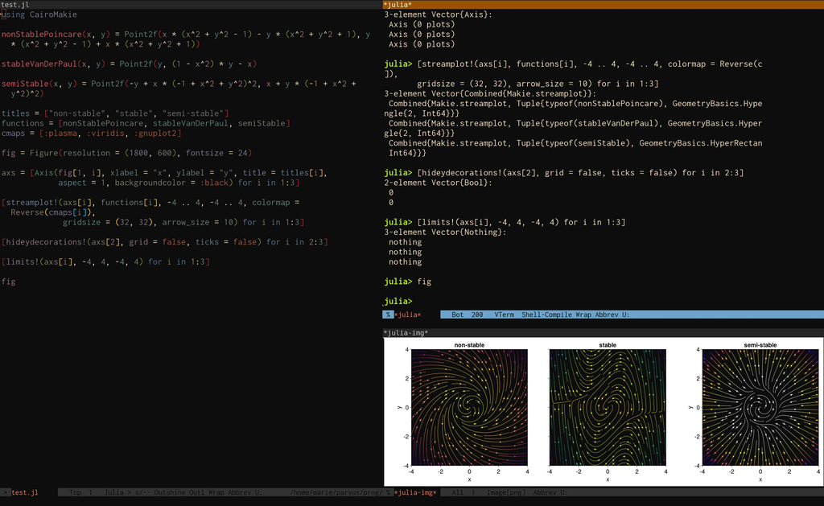

Code from [Beautiful Makie](https://beautiful.makie.org/dev/examples/2d/streamplot/poincare_vander)

ESS also provides an IDE for Julia, but it does not allow for the funky Julia-specific REPL

Another sophisticated option is to use [julia-mode](https://github.com/JuliaEditorSupport/julia-emacs) with the julia-snail package